# CARET

Let’s try to get baseline DX from DTI. First, some data cleaning:

```r
library(caret)
library(doParallel)
# # for replication purposes
# set.seed(107)
source('~/ncr_notebooks/baseline_prediction//src/aux_functions.R')
gf_fname = '~/data/baseline_prediction/dti_match_02092017.csv'
data_fname = '~/data/baseline_prediction/dti_match_02092017.csv'
gf = read.csv(gf_fname)
group_var = 'DX_A'
all_data = read.csv(data_fname)
mrn_gf = unique(gf[, c('ID', group_var)])
idx = all_data$DTI_select < 2 & all_data$QC_GRADE < 3
data = all_data[idx,]
ldata = merge(mrn_gf, data, by.x='ID', by.y='ID')
eval(parse(text=sprintf('groups = ldata$\"%s.y\"', group_var)))
idx = groups=='NV' | groups=='ADHD'
groups = factor(groups[idx])
ldata = ldata[idx,]
phen_vars = c(which(grepl("MASKID", colnames(ldata))),
              which(grepl("^FA_", colnames(ldata))),
              which(grepl("^AD_", colnames(ldata))),
              which(grepl("^RD_", colnames(ldata)))
              )
ldata = ldata[, phen_vars]
```

At this point we have only clean DTI data in ldata. Let’s check whether they have any remaining outliers in the property averages:

```r
mean_data = read.csv('~/data/baseline_prediction/dti_tortoiseExported_meanTSA_02012017.csv')
# remove data columns from mean_data to avoid duplicates
phen_idx = grepl("^FA_", colnames(mean_data)) |
            grepl("^AD_", colnames(mean_data)) |
            grepl("^RD_", colnames(mean_data))
mean_data = mean_data[, !phen_idx]
ldata2 = merge(ldata, mean_data, by.x='MASKID', by.y='Mask.ID...Scan')
par(mfrow=c(1, 3))
nbreaks = 40
hist(ldata2$fa_avg, breaks=nbreaks)
hist(ldata2$ad_avg, breaks=nbreaks)
```

[figure not shown]

```r
hist(ldata2$rd_avg, breaks=nbreaks)
```

Cleaning up based on visual cutoffs:

```r
rm_me = ldata2$fa_avg < .4 | ldata2$ad_avg < 1.18 | ldata2$rd_avg > .7
ldata = ldata2[!rm_me, ]
groups = groups[!rm_me]
```

Now we keep only the variables we’ll be using for predictions, and start classification:

```r
phen_vars = c(which(grepl("^FA_", colnames(ldata))),
              which(grepl("^AD_", colnames(ldata))),
              which(grepl("^RD_", colnames(ldata)))
              )
ldata = ldata[, phen_vars]
ncv = 5
nrepeatcv = 2
nsplits = 5
train_test_ratio = .85
root_fname = '~/tmp/dti_NVvsADHD_3props_pca'
# saving output
sink(sprintf('%s.log', root_fname), append=FALSE, split=TRUE)
ncores = detectCores(all.tests = FALSE, logical = TRUE)
njobs = ncores - 3
run_models = c('rndForest', 'lr', 'rsvm', 'xgb') #c('rndForest', 'lr', 'lsvm', 'rsvm', 'xgb', 'gbm')
inTrain = createDataPartition(y = groups,
                              times= nsplits,
                              p=train_test_ratio)
metric = "ROC"
default_preproc = c("pca")
default_options = list(n.comp=15)
ctrl_cv <- trainControl(method = "repeatedcv",
                        number = ncv,
                        repeats = nrepeatcv,
                        classProbs = TRUE,
                        returnData = FALSE,
                        summaryFunction = twoClassSummary,
                        preProcOptions = default_options,
                        search='grid')
source('~/ncr_notebooks/baseline_prediction/src/do_classification.R')
```

```
Working on split 1 of 5
Running random forests
   user  system elapsed
 13.106   3.361   3.923

Running logistic regression
```

```
   user  system elapsed
  4.573   1.445   1.380

Running RBF SVM
```

```
   user  system elapsed
 71.834   2.529  14.378

Running XGBoost
```

```
   user  system elapsed
211.313   4.006  43.390

Working on split 2 of 5
Running random forests
   user  system elapsed
 41.507   2.068   3.474

Running logistic regression
   user  system elapsed
  4.366   1.144   1.620

Running RBF SVM
   user  system elapsed
 78.300   2.885  15.501

Running XGBoost
   user  system elapsed
217.301   4.175  39.733

Working on split 3 of 5
Running random forests
   user  system elapsed
 41.520   2.122   2.961

Running logistic regression
   user  system elapsed
  4.068   1.124   1.432

Running RBF SVM
   user  system elapsed
 79.036   2.761  15.109

Running XGBoost
   user  system elapsed
216.372   3.894  38.603

Working on split 4 of 5
Running random forests
   user  system elapsed
```

[output cut: 15 more lines]

```
Running random forests
   user  system elapsed
 41.929   1.914   2.833

Running logistic regression
   user  system elapsed
  4.020   1.041   1.412

Running RBF SVM
   user  system elapsed
 80.843   2.719  15.332

Running XGBoost
   user  system elapsed
218.112   3.814  38.645
```

Let’s plot different metrics on the test data:

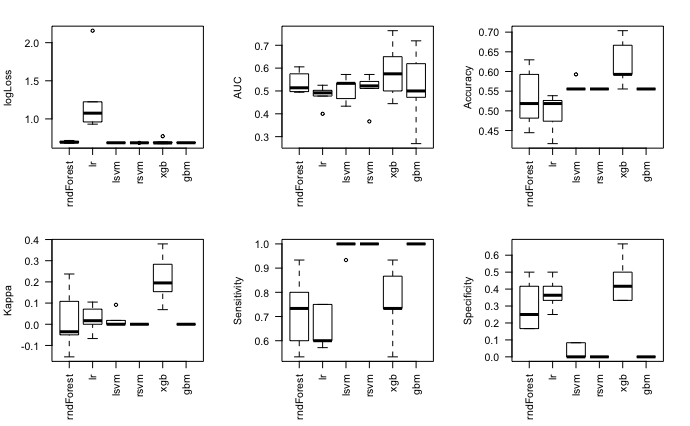

```r
source('~/ncr_notebooks/baseline_prediction/src/do_metrics_plots.R')
```

Looks like XGB does best, mostly because it has a good tradeoff between sensititivy and specificity. We can explore it further too… Also, given the time they’re taking to run, gbm and lsvm don’t seem to be worth the effort, at least not with their current search grids.

These are the results if we do PCA as a preprocessing step.

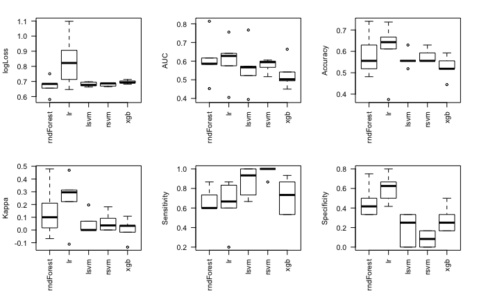

```r
source('~/ncr_notebooks/baseline_prediction/src/do_metrics_plots.R')
```

And then we run PCA again, just to check if results are consistent (removed center and scale, which are superfluous in this case):

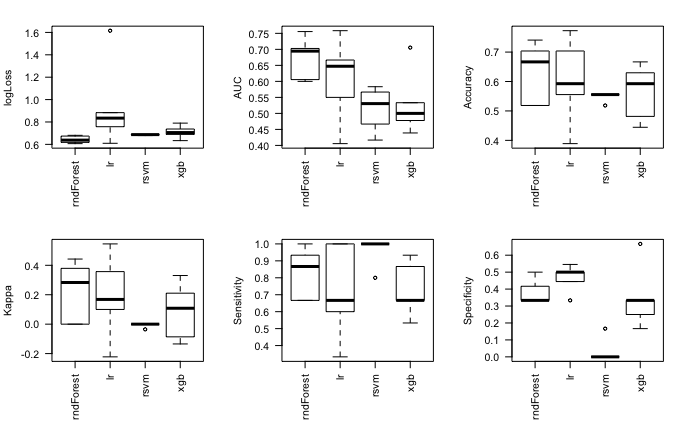

```r
source('~/ncr_notebooks/baseline_prediction/src/do_metrics_plots.R')
```

Here’s PCA only within FA:

```r
phen_vars = c(which(grepl("^FA_", colnames(ldata))))
ldata = ldata[, phen_vars]
ncv = 5
nrepeatcv = 2
nsplits = 5
train_test_ratio = .85
root_fname = '~/tmp/dti_NVvsADHD_3props_pca'
# saving output
sink(sprintf('%s.log', root_fname), append=FALSE, split=TRUE)
ncores = detectCores(all.tests = FALSE, logical = TRUE)
njobs = ncores - 3
run_models = c('rndForest', 'lr', 'rsvm', 'xgb') #c('rndForest', 'lr', 'lsvm', 'rsvm', 'xgb', 'gbm')
inTrain = createDataPartition(y = groups,
                              times= nsplits,
                              p=train_test_ratio)
metric = "ROC"
default_preproc = c("pca")
default_options = list(n.comp=15)
ctrl_cv <- trainControl(method = "repeatedcv",
                        number = ncv,
                        repeats = nrepeatcv,
                        classProbs = TRUE,
                        returnData = FALSE,
                        summaryFunction = twoClassSummary,
                        preProcOptions = default_options,
                        search='grid')
source('~/ncr_notebooks/baseline_prediction/src/do_classification.R')
```

```
Working on split 1 of 5
Running random forests
   user  system elapsed
 35.138   1.510   1.644

Running logistic regression
   user  system elapsed
  2.481   0.887   1.176

Running RBF SVM
   user  system elapsed
 45.951   2.271   9.134

Running XGBoost
   user  system elapsed
157.421   3.421  28.857

Working on split 2 of 5
Running random forests
   user  system elapsed
 26.323   1.352   1.616

Running logistic regression
   user  system elapsed
  3.214   1.097   1.214

Running RBF SVM
   user  system elapsed
 50.445   2.454  10.203

Running XGBoost
   user  system elapsed
137.995   3.244  30.446

Working on split 3 of 5
Running random forests
   user  system elapsed
 50.104   2.036   1.673

Running logistic regression
```

[output cut: 29 more lines]

```
Running random forests
   user  system elapsed
 46.951   1.315   1.597

Running logistic regression
   user  system elapsed
  5.375   1.538   1.240

Running RBF SVM
maximum number of iterations reached 3.286396e-05 3.28638e-05   user  system elapsed
 51.944   2.354  10.287

Running XGBoost
   user  system elapsed
168.478   4.912  31.052
```

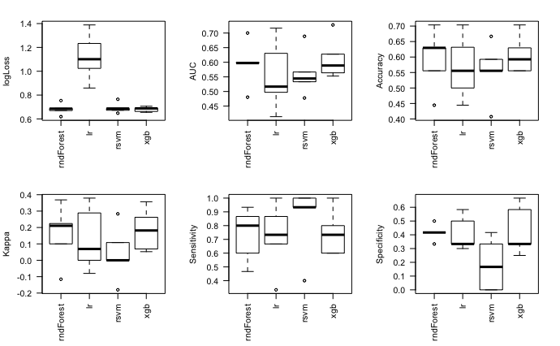

```r
source('~/ncr_notebooks/baseline_prediction/src/do_metrics_plots.R')
```

And then we run PCA within AD and RD only:

```r
phen_vars = c(which(grepl("^AD_", colnames(ldata))),
              which(grepl("^RD_", colnames(ldata))))
ldata = ldata[, phen_vars]
ncv = 5
nrepeatcv = 2
nsplits = 5
train_test_ratio = .85
root_fname = '~/tmp/dti_NVvsADHD_3props_pca'
# saving output
sink(sprintf('%s.log', root_fname), append=FALSE, split=TRUE)
ncores = detectCores(all.tests = FALSE, logical = TRUE)
njobs = ncores - 3
run_models = c('rndForest', 'lr', 'rsvm', 'xgb') #c('rndForest', 'lr', 'lsvm', 'rsvm', 'xgb', 'gbm')
inTrain = createDataPartition(y = groups,
                              times= nsplits,
                              p=train_test_ratio)
metric = "ROC"
default_preproc = c("pca")
default_options = list(n.comp=15)
ctrl_cv <- trainControl(method = "repeatedcv",
                        number = ncv,
                        repeats = nrepeatcv,
                        classProbs = TRUE,
                        returnData = FALSE,
                        summaryFunction = twoClassSummary,
                        preProcOptions = default_options,
                        search='grid')
source('~/ncr_notebooks/baseline_prediction/src/do_classification.R')
```

```
Working on split 1 of 5
Running random forests
   user  system elapsed
 11.098   3.350   3.197

Running logistic regression
   user  system elapsed
  3.525   1.313   1.295

Running RBF SVM
   user  system elapsed
 55.071   3.389  11.980

Running XGBoost
   user  system elapsed
207.567   6.329  34.968

Working on split 2 of 5
Running random forests
   user  system elapsed
 35.535   1.960   2.243

Running logistic regression
   user  system elapsed
  4.582   1.262   1.341

Running RBF SVM
   user  system elapsed
 65.756   3.838  11.942

Running XGBoost
   user  system elapsed
200.805   5.067  34.788

Working on split 3 of 5
Running random forests
   user  system elapsed
 35.479   1.817   2.459

Running logistic regression
```

[output cut: 29 more lines]

```
Running random forests
   user  system elapsed
 34.117   1.401   2.126

Running logistic regression
   user  system elapsed
  5.307   1.339   1.268

Running RBF SVM
   user  system elapsed
 67.718   2.556  12.251

Running XGBoost
   user  system elapsed
195.817   3.334  32.638
```

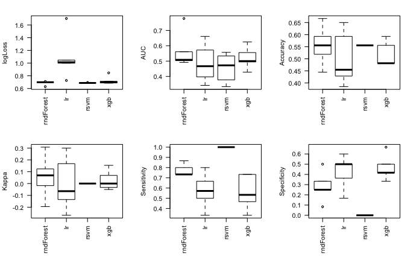

```r
source('~/ncr_notebooks/baseline_prediction/src/do_metrics_plots.R')
```

It looks like we should either do PCA using everything, which boosts LR and rndForst, or not do it at all, which helps xgb.